# Ejercicio_2

Gabriela Chavez

2026-08-20

### Ejercicio 1:Modifique el modelo SIR con dinámica vital para incluir un compartimento expuesto (E), creando un modelo SEIR.

#### -Initial population: 1000 (with 990 susceptible, 5 exposed, 4 infected, and 1 recovered)

#### -Transmission rate ($\beta$): 0.002

#### -Progression rate from exposed to infected ($\sigma$): 0.1

#### -Recovery rate ($\gamma$): 0.05

#### -Birth/death rate ($\mu$): 0.01

#### -Transmission is density-dependen

#### **Definir las condiciones iniciales y los parametros para el modelo SEIR**

```r
condiciones_inciales <- c(S = 990, E= 5, I=4, R=1 )
```

```r
parameters <- c(beta = 0.002, sigma = 0.1, gamma = 0.05, mu = 0.01)
```

#### **Escribe una función en R que represente el modelo SEIR con los nacimientos y muertes**

```r
seir_model <- function(time, state, parameters){
   with(as.list(c(state,parameters)), {
     N <- (S+E+I+R)
     dS <- mu *N -beta * S  * I - mu * S
     dE <- beta * S * I  - sigma * E - mu * E
     dI <- sigma * E  - gamma * I - mu * I
     dR <- gamma * I - mu * R

  list(c(dS,dE,dI,dR))
  })
}
```

#### **Resuelve el modelo por 200 días**

```r
library(deSolve)
tiempo <- seq(0,200, by=1)
seirdv <- ode(condiciones_inciales,tiempo,seir_model,parameters)
seirdv<- as.data.frame(seirdv)
seirdv
```

```
##     time         S         E          I          R
## 1      0 990.00000   5.00000   4.000000   1.000000
## 2      1 981.76407  12.42105   4.613449   1.201423
## 3      2 971.80089  20.80165   5.948340   1.449119
## 4      3 958.71791  31.38457   8.116703   1.780823
## 5      4 940.92062  45.48972  11.347279   2.242377
## 6      5 916.49104  64.62325  15.992142   2.893570
## 7      6 883.14574  90.50025  22.539558   3.814452
## 8      7 838.33475 124.93093  31.622160   5.112162
## 9      8 779.58234 169.48645  44.003570   6.927639
## 10     9 705.17862 224.86185  60.518958   9.440572
## 11    10 615.23465 289.95341  81.942325  12.869621
## 12    11 512.83930 360.92895 108.767878  17.463871
## 13    12 404.64033 430.93898 140.938776  23.481912
## 14    13 299.98362 491.23055 177.627489  31.158341
```

[output cut: 187 more lines]

#### **Haz una gráfica con los resultados con ggplot2**

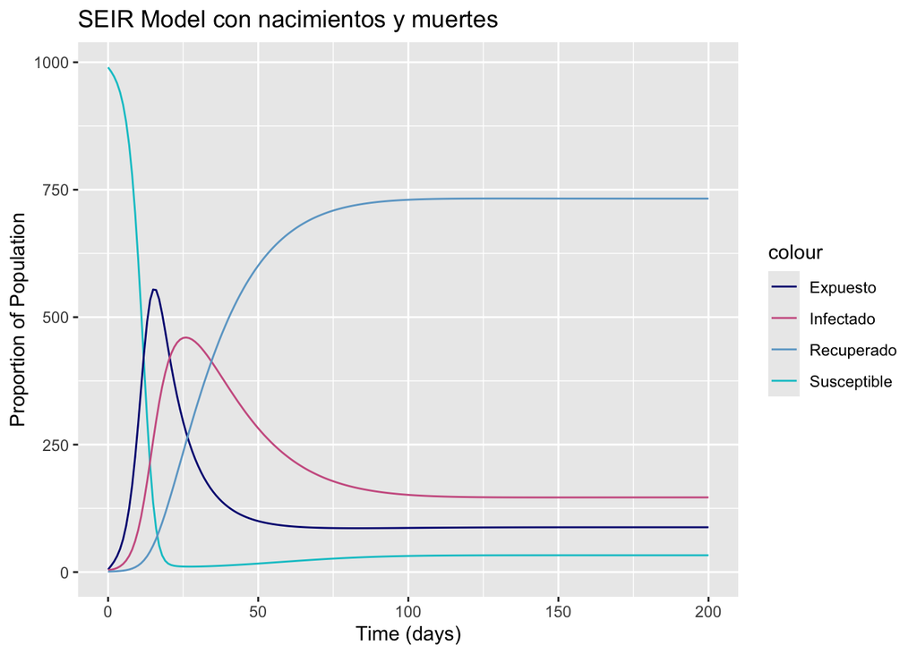

```r
library(ggplot2)
ggplot(seirdv, aes(x=tiempo)) +
  geom_line(aes(y = S, color= "Susceptible")) +
  geom_line(aes(y = E, color= "Expuesto"))   +
  geom_line(aes(y = I, color= "Infectado"))  +
  geom_line(aes(y = R, color= "Recuperado")) +
  labs(title = "SEIR Model con nacimientos y muertes", x = "Time (days)", y = "Proportion of Population") +
  scale_color_manual(values = c("Susceptible" = "turquoise3", "Expuesto" = "navyblue", "Infectado" = "hotpink3", "Recuperado" = "skyblue3"))
```

#### -Tasa de muertes induxidas-infección 𝛼:0.02

```r
condiciones <- c(S = 990, I = 10)
parametros <- c(beta = 0.1, alfa = 0.02)
```

```r
library(deSolve)
SI <- function(time, states, parameters){
   with(as.list(c(states,parameters)), {

     dS <-  - (beta * S  * I)
     dI <- (beta * S * I) - (alfa * I)

  list(c(dS,dI))
  })

}
```

```r
SID <- ode(condiciones,tiempo,SI,parametros)
SID <- as.data.frame(SID)
```

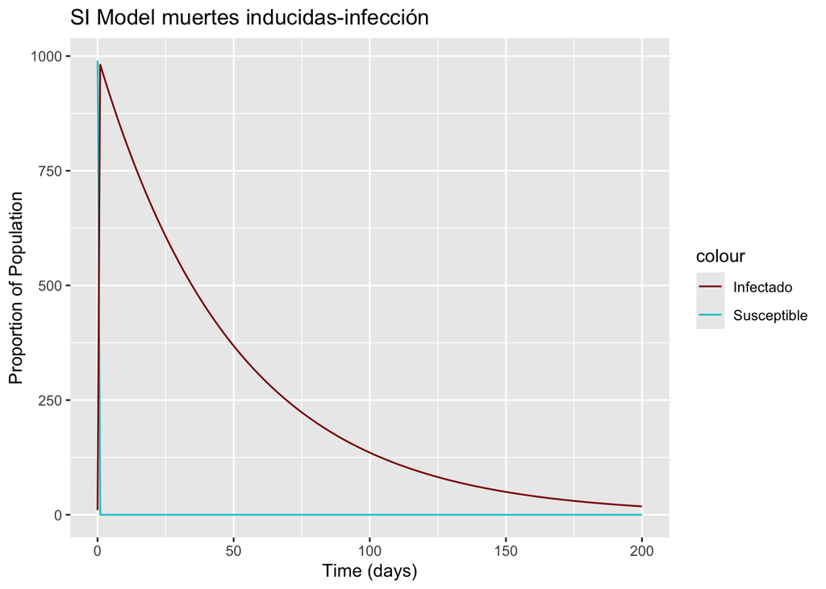

```r
library(ggplot2)
ggplot(SID, aes(x=tiempo)) +
  geom_line(aes(y = S, color= "Susceptible")) +
  geom_line(aes(y = I, color= "Infectado"))   +

  labs(title = "SI Model muertes inducidas-infección", x = "Time (days)", y = "Proportion of Population") +
  scale_color_manual(values = c("Susceptible" = "turquoise3",  "Infectado" = "red4"))
```

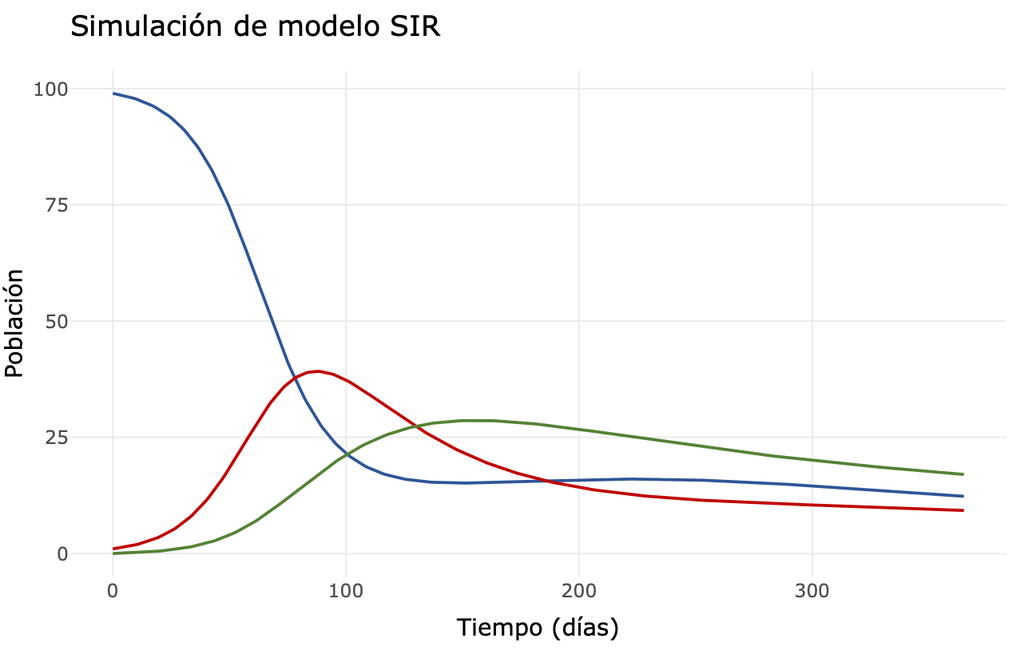

0.01 alfa

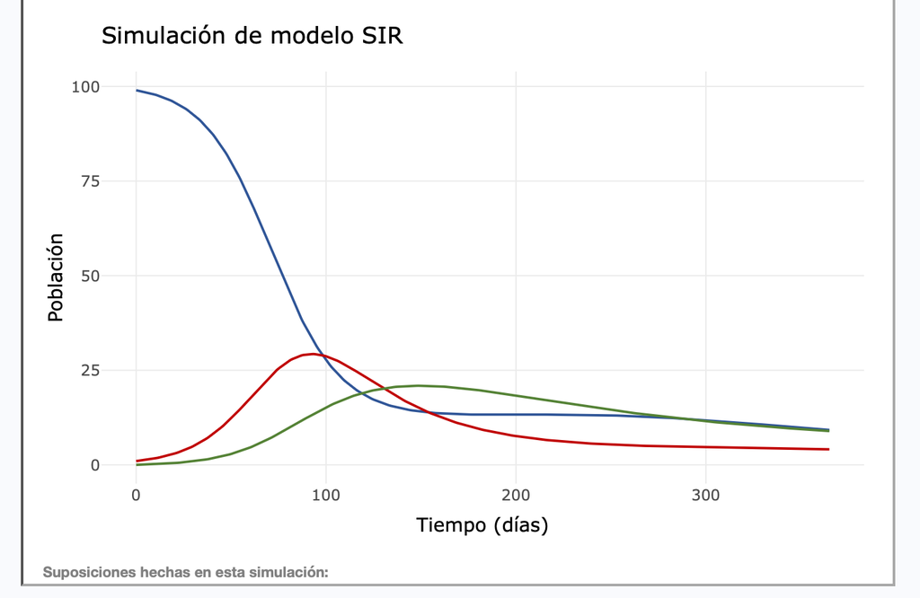

0.02 alfa

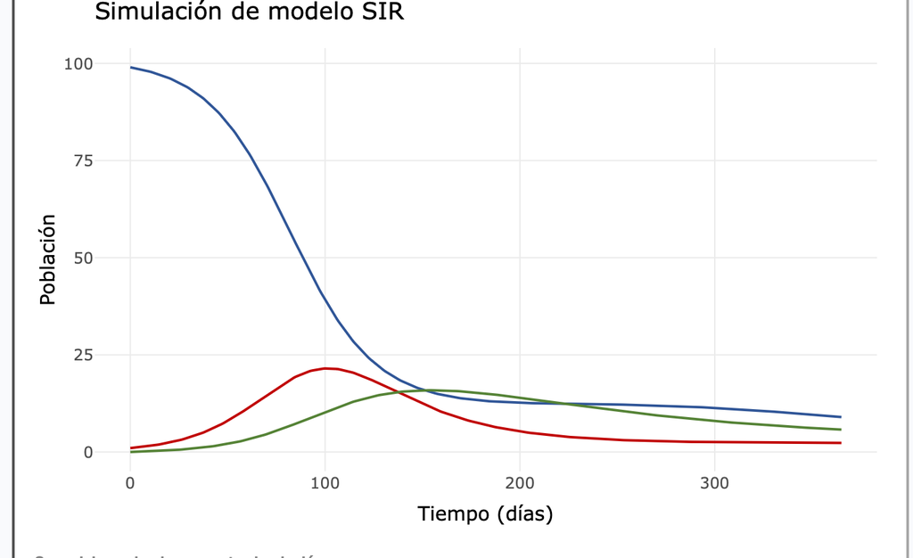

0.03 alfa

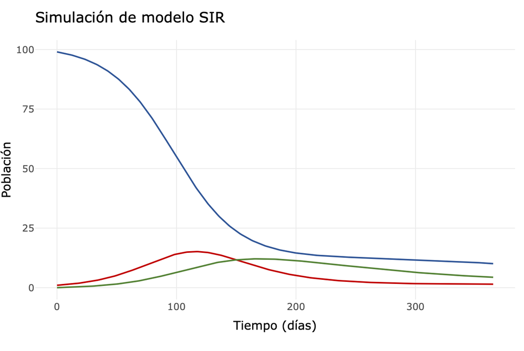

0.04 alfa

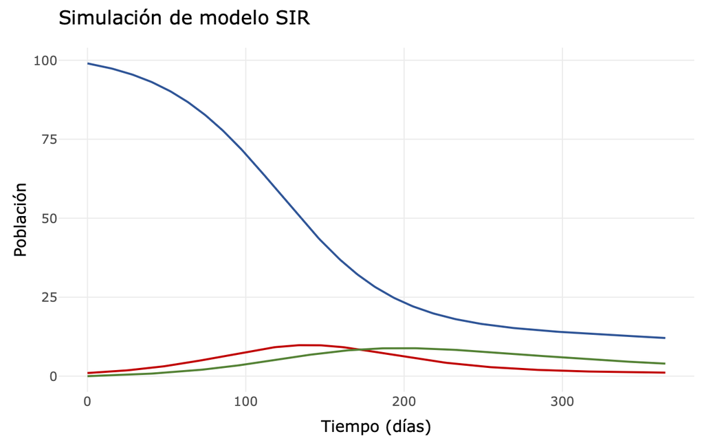

0.05 alfa

### Ejercicio 4: escribe una función de R llamada seir_vital_dynamics que represente un modelo SIR frecuenso-dependiente que incluya nacimientos/muertes naturales y muertes inducidas por infección.

```r
sir_vital_dynamics <- function(time, states, parameters){
  with(as.list(c(states,parameters)),{
       # Calcula total de la población
    N <- (S + I + R)

    # Ecuaciones diferenciales
    dS <- mu * N - beta * S * I - mu * S
    dI <- beta * S * I/ N - gamma * I - mu * I - alfa*I
    dR <- gamma * I - mu * R


  list(c(dS,dI))
  })
}
```

### Preguntas:

#### • Para un modelo SIR con demografía y mortalidad inducida por la infección

##### - Comparen este valor con el RO del modelo SIR básico.

```r
R0 <- parameters["beta"]/parameters["gamma"]
R0
```

```
## beta
## 0.04
```

```r
R0DEMO <- ((parameters["beta"])/(parameters["gamma"]+parameters["mu"]+parametros ["alfa"]))
R0DEMO
```

```
##  beta
## 0.025
```

##### • **¿Por qué la incorporación de mu y alpha modifica R0?**

**R:** Porque al haber una disminución en la población la cantidad de personas que se pueden infectar a partir de un individuo son menores.

##### • Umbral de susceptibles

##### • Calculen la proporción crítica de susceptibles, sc=1/R0

```r
SC <- 1/R0
SC
```

```
## beta
##   25
```

```r
SCDEMO <- 1/R0DEMO
SCDEMO
```

```
## beta
##   40
```

**¿Qué determina este umbral y cómo cambia al incorporar alpha?** **R:** Esta se calcula sacando el inverso de R0 y al contario de lo que pasa en R0 este aumenta al incorporar alfa.

##### • Elección de la estructura del modelo

##### • Considerando la relación entre el periodo latente y el periodo infeccioso de la varicela.

• **¿es más apropiado representarla con un modelo SIR o SEIR? Justifiquen su elección con base en la historia natural de la infección.** **R:** SEIR, la varicela tiene un periodo de incubación tras la exposición a esta infección, por lo que el SEIR al incluir este compartimento es más apropiado

• Diseño de una intervención -Elijan una intervención para controlar la transmisión. **Expliquen qué componente del modelo modificaría beta, gamma, S, y predigan cómo cambiarían R0, el umbral de susceptibles y la infección** **R:** Utilizar vitaminas que ayuden a mejorar el sistema inmune de los individuos susceptibles, el componente que se modificaria seria beta, este diminuye y al disminuir beta la R0 se ve afectada, siendo incapaz de mantener activa la infección en la población.